# U.S. Census Income Classification

Author

Prabin Roka

# 1 Introduction

In this project, we aim to predict whether an individual earns more than $50,000 annually using U.S. Census demographic data. The problem is a binary classification task involving features like age, education, occupation, hours worked, and capital gains/losses. The project gave me practice preparing demographic data, comparing classification models, and interpreting evaluation results.

The dataset consists of:

- **Training set**: 35,000 records with demographic predictors, an imported row identifier, and the target (`income`)
- **Test set**: 13,840 rows with the same features (excluding `income`)

# 2 Loading and Inspecting Data

```r
# Loading training and test datasets
train_data <- read_csv("census_train.csv") |> clean_names()
```

```
──────────────────────────────────────────────────────── Delimiter: "," chr
(9): workclass, education, marital-status, occupation, relationship, rac... dbl
(7): ...1, age, fnlwgt, education-num, capital-gain, capital-loss, hours...
```

```r
test_data <- read_csv("census_test.csv") |> clean_names()
```

```
──────────────────────────────────────────────────────── Delimiter: "," chr
(8): workclass, education, marital-status, occupation, relationship, rac... dbl
(7): ...1, age, fnlwgt, education-num, capital-gain, capital-loss, hours...
```

```r
#glimpse(train_data)

# # Checking column names and structure
colnames(train_data)
```

```
 [1] "x1"             "age"            "workclass"      "fnlwgt"
 [5] "education"      "education_num"  "marital_status" "occupation"
 [9] "relationship"   "race"           "sex"            "capital_gain"
[13] "capital_loss"   "hours_per_week" "native_country" "income"
```

# 3 Exploratory Data Analysis (EDA) and Preprocessing

### 3.0.1 Data Cleaning

```r
# Converting " ?" to NA only in character columns
train_data <- train_data |> mutate(across(where(is.character), ~na_if(.x, " ?")))
test_data  <- test_data  |> mutate(across(where(is.character), ~na_if(.x, " ?")))

# Fixing inconsistent income labels and converting to factor
train_data <- train_data |>
  mutate(income = str_trim(income),
         income = if_else(income == ">50K", "1", "0"),
         income = factor(income))

# Checking missing values summary
train_data |> summarise(across(everything(), ~sum(is.na(.))))
```

| x1 | age | workclass | fnlwgt | education | education_num | marital_status | occupation | relationship | race | sex | capital_gain | capital_loss | hours_per_week | native_country | income |
| --- | --- | --- | --- | --- | --- | --- | --- | --- | --- | --- | --- | --- | --- | --- | --- |
| 0 | 0 | 0 | 0 | 0 | 0 | 0 | 0 | 0 | 0 | 0 | 0 | 0 | 0 | 0 | 0 |

```r
test_data |> summarise(across(everything(), ~sum(is.na(.))))
```

| x1 | age | workclass | fnlwgt | education | education_num | marital_status | occupation | relationship | race | sex | capital_gain | capital_loss | hours_per_week | native_country |
| --- | --- | --- | --- | --- | --- | --- | --- | --- | --- | --- | --- | --- | --- | --- |
| 0 | 0 | 0 | 0 | 0 | 0 | 0 | 0 | 0 | 0 | 0 | 0 | 0 | 0 | 0 |

### 3.0.2 Class Imbalance

We found that only **15.9%** of individuals in the dataset earn more than $50K. Because the lower-income class accounts for about 84% of the training data, accuracy alone is not enough to judge model performance.

```r
train_data |>
  count(income) |>
  mutate(proportion = n / sum(n))
```

| income | n | proportion |
| --- | --- | --- |
| 0 | 29419 | 0.8405429 |
| 1 | 5581 | 0.1594571 |

### 3.0.3 Visualizing Key Distributions

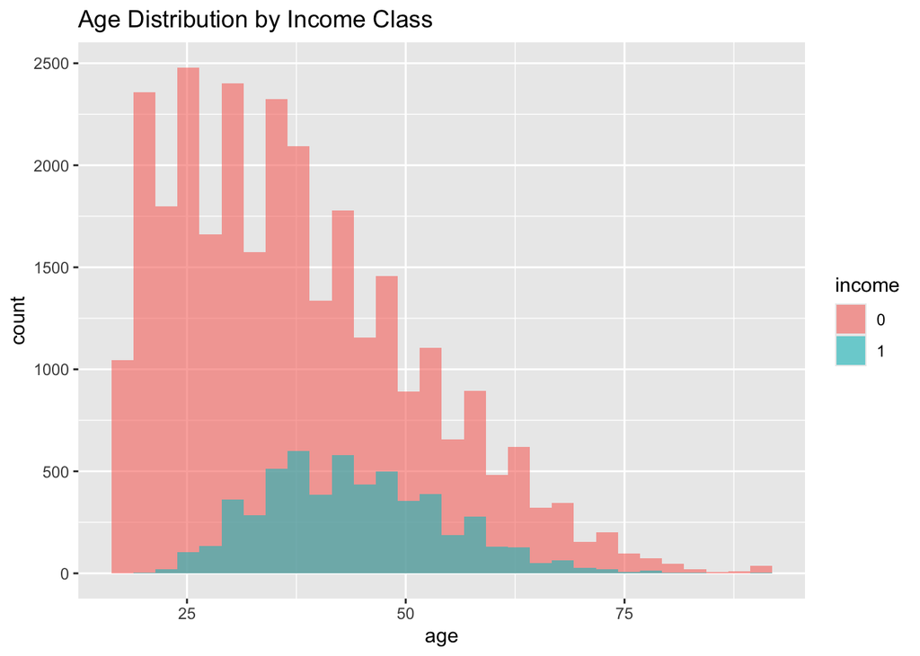

```r
ggplot(train_data, aes(x = age, fill = income)) +
  geom_histogram(bins = 30, position = "identity", alpha = 0.6) +
  labs(title = "Age Distribution by Income Class")
```

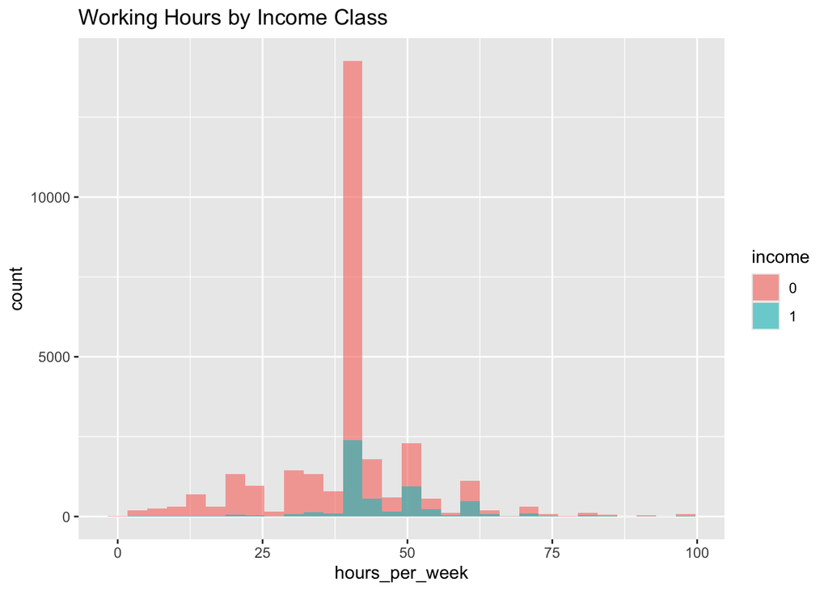

```r
ggplot(train_data, aes(x = hours_per_week, fill = income)) +
  geom_histogram(bins = 30, position = "identity", alpha = 0.6) +
  labs(title = "Working Hours by Income Class")
```

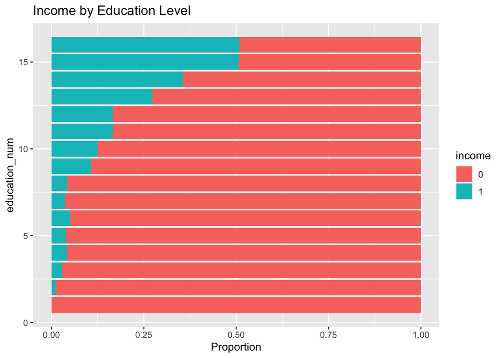

```r
ggplot(train_data, aes(x = education_num, fill = income)) +
  geom_bar(position = "fill") +
  coord_flip() +
  labs(title = "Income by Education Level", y = "Proportion")
```

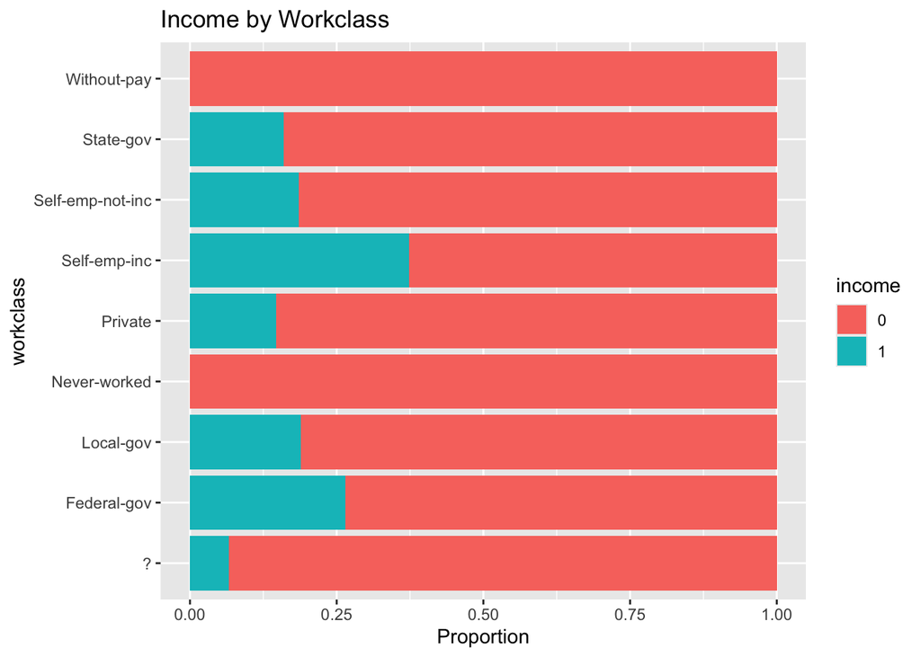

```r
ggplot(train_data, aes(x = workclass, fill = income)) +
  geom_bar(position = "fill") +
  coord_flip() +
  labs(title = "Income by Workclass", y = "Proportion")
```

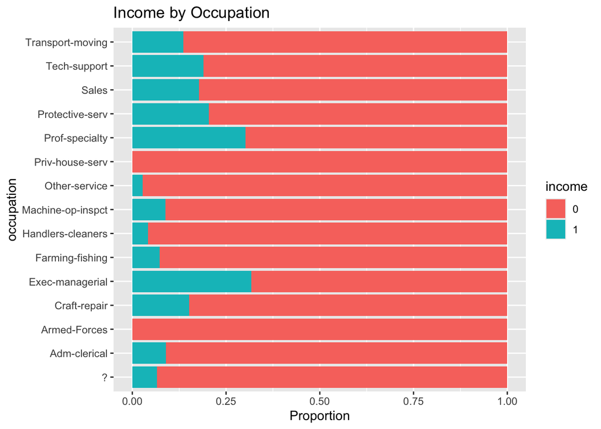

```r
ggplot(train_data, aes(x = occupation, fill = income)) +
  geom_bar(position = "fill") +
  coord_flip() +
  labs(title = "Income by Occupation", y = "Proportion")
```

### 3.0.4 Visual Analysis

- **Age** and **Hours-per-week** were positively associated with higher income.
- **Education** and **Workclass** showed clear income stratification.
- **Occupation** categories such as Exec-managerial and Prof-specialty skewed toward higher income.

# 4 Preprocessing and Feature Engineering

A preprocessing pipeline was created using `recipes`:

- Removed the `fnlwgt` variable.
- Created dummy variables for categorical predictors.
- Removed zero-variance predictors.
- Normalized numeric predictors.(e.g., age, capital gain)

  ```r
  census_recipe <- recipe(income ~ ., data = train_data) |>
    step_rm(fnlwgt) |>  # Remove non-informative feature
    step_novel(all_nominal_predictors()) |>  # <-- NEW: handles unseen levels
    step_dummy(all_nominal_predictors()) |>  # One-hot encode categorical vars
    step_zv(all_predictors()) |>  # Drop zero-variance features
    step_normalize(all_numeric_predictors())  # Normalize numeric vars
  ```

# 5 Modeling and Model Selection

To compare approaches for predicting income class, we trained and evaluated three models: **Logistic Regression**, **Decision Tree**, and **Random Forest**. Each model used the same preprocessed data and was assessed with 5-fold stratified cross-validation. Evaluation metrics included accuracy, precision, recall, and ROC AUC.

### 5.0.1 **Logistic Regression**

- We trained a logistic regression model using 5-fold stratified cross-validation. Performance was measured using ROC AUC, precision, recall, and accuracy.

  ```r
  # logistic regression model specification
  log_reg_spec <- logistic_reg() |>
    set_engine("glm") |>
    set_mode("classification")

  # workflow with recipe + model
  log_reg_wf <- workflow() |>
    add_model(log_reg_spec) |>
    add_recipe(census_recipe)

  # Cross-validation folds (5-fold stratified)
  set.seed(427)
  census_folds <- vfold_cv(train_data, v = 5, strata = income)

  # Fitting model with resampling
  log_reg_results <- fit_resamples(
    log_reg_wf,
    resamples = census_folds,
    metrics = metric_set(roc_auc, accuracy, precision, recall)
  )
  ```

  ```r
  collect_metrics(log_reg_results)
  ```

  | .metric | .estimator | mean | n | std_err | .config |
  | --- | --- | --- | --- | --- | --- |
  | accuracy | binary | 0.8491143 | 5 | 0.0018452494 | Preprocessor1_Model1 |
  | precision | binary | 0.8718795 | 5 | 0.0007665424 | Preprocessor1_Model1 |
  | recall | binary | 0.9618274 | 5 | 0.0017034747 | Preprocessor1_Model1 |
  | roc_auc | binary | 0.8551909 | 5 | 0.0025155625 | Preprocessor1_Model1 |

  Logistic regression is a straightforward and interpretable model. It performed well, achieving:
  - Accuracy: 0.849
  - Precision: 0.872
  - Recall: 0.962
  - ROC AUC: 0.855

  However, it slightly underperformed in overall accuracy compared to other models.

### 5.0.2 **Decision Tree(**Simple model with intuitive structure)

  ```r
  # decision tree model
  tree_spec <- decision_tree() |>
    set_engine("rpart") |>
    set_mode("classification")

  # workflow with the same recipe
  tree_wf <- workflow() |>
    add_model(tree_spec) |>
    add_recipe(census_recipe)

  # Fitting using cross-validation
  set.seed(427)
  tree_results <- fit_resamples(
    tree_wf,
    resamples = census_folds,
    metrics = metric_set(roc_auc, accuracy, precision, recall)
  )

  collect_metrics(tree_results)
  ```

  | .metric | .estimator | mean | n | std_err | .config |
  | --- | --- | --- | --- | --- | --- |
  | accuracy | binary | 0.8595428 | 5 | 0.0009097793 | Preprocessor1_Model1 |
  | precision | binary | 0.8713848 | 5 | 0.0008063657 | Preprocessor1_Model1 |
  | recall | binary | 0.9771236 | 5 | 0.0007018932 | Preprocessor1_Model1 |
  | roc_auc | binary | 0.8149710 | 5 | 0.0014404828 | Preprocessor1_Model1 |

  This model slightly outperformed logistic regression:
  - Accuracy: 0.8595
  - Precision: 0.871
  - Recall: 0.977
  - ROC AUC: 0.815

  The Decision Tree had slightly higher accuracy than Logistic Regression, but a lower cross-validation ROC AUC. The recall shown here refers to income at or below $50,000, rather than the higher-income class.

### 5.0.3 Random Forest (Tuned)

```r
# Random Forest model
set.seed(427)
census_folds <- vfold_cv(train_data, v = 5, strata = income)

rf_spec <- rand_forest(mtry = tune(), trees = 500, min_n = tune()) |>
  set_engine("ranger") |>
  set_mode("classification")

# Workflow
rf_wf <- workflow() |>
  add_model(rf_spec) |>
  add_recipe(census_recipe)

# Hyperparameter tuning with grid search
set.seed(427)
rf_results <- tune_grid(
  rf_wf,
  resamples = census_folds,
  grid = 5,
  metrics = metric_set(roc_auc, accuracy, precision, recall)
)
```

```
i Creating pre-processing data to finalize unknown parameter: mtry
```

```r
collect_metrics(rf_results)
```

| mtry | min_n | .metric | .estimator | mean | n | std_err | .config |
| --- | --- | --- | --- | --- | --- | --- | --- |
| 18 | 11 | accuracy | binary | 0.8584285 | 5 | 0.0010327923 | Preprocessor1_Model1 |
| 18 | 11 | precision | binary | 0.8860437 | 5 | 0.0010456508 | Preprocessor1_Model1 |
| 18 | 11 | recall | binary | 0.9543153 | 5 | 0.0006198299 | Preprocessor1_Model1 |
| 18 | 11 | roc_auc | binary | 0.8731747 | 5 | 0.0021502316 | Preprocessor1_Model1 |
| 88 | 3 | accuracy | binary | 0.8507142 | 5 | 0.0009933588 | Preprocessor1_Model2 |
| 88 | 3 | precision | binary | 0.8882065 | 5 | 0.0011931084 | Preprocessor1_Model2 |
| 88 | 3 | recall | binary | 0.9408207 | 5 | 0.0010536780 | Preprocessor1_Model2 |
| 88 | 3 | roc_auc | binary | 0.8582541 | 5 | 0.0024086687 | Preprocessor1_Model2 |
| 56 | 26 | accuracy | binary | 0.8582571 | 5 | 0.0006941584 | Preprocessor1_Model3 |
| 56 | 26 | precision | binary | 0.8875153 | 5 | 0.0009469782 | Preprocessor1_Model3 |

[output cut: 10 more lines]

```r
# View best model
rf_best <- select_best(rf_results, metric = "accuracy")
```

We used grid search tuning over `mtry` and `min_n` to optimize for accuracy. The selected configuration had the following reported cross-validation results:

- Accuracy: **0.8595**
- Precision: **0.8878**
- Recall: 0.9534
- ROC AUC: **0.8691**

| Model | Accuracy | Precision | Recall | ROC AUC |
| --- | --- | --- | --- | --- |
| Logistic Regression | 0.849 | 0.872 | 0.962 | 0.855 |
| Decision Tree | 0.8595 | 0.871 | 0.977 | 0.815 |
| Random Forest | **0.8595** | **0.8878** | 0.9534 | **0.8691** |

Random Forest and the Decision Tree had nearly identical reported accuracy. Random Forest had higher reported precision and ROC AUC than the Decision Tree, while Logistic Regression had lower accuracy. I selected the tuned Random Forest for the final predictions based on this comparison.

These are cross-validation estimates, not scores from the unlabeled test set. Precision and recall use the first income factor level, `0` (income at or below $50,000), as the event in this workflow. They should not be interpreted as precision or recall for individuals earning more than $50,000. These results do not establish performance on new labeled data.

The table records results from the original run and should be checked against fresh model output if the analysis is rerun.

# 6 Final Model and Predictions

We fit the tuned Random Forest model on the entire training dataset and generated predictions for the 13,840 test set individuals. The binary prediction vector (0 = ≤$50K, 1 = >$50K) was exported as a CSV file without row names or a header:

```r
# Finalizing the workflow with the best parameters
final_rf_wf <- finalize_workflow(rf_wf, rf_best)

# Fitting final model
final_rf_fit <- fit(final_rf_wf, data = train_data)
rf_predictions <- predict(final_rf_fit, new_data = test_data, type = "class")

# Converting factor to numeric 0/1
prediction_vector_rf <- as.integer(as.character(rf_predictions$.pred_class))
write.table(prediction_vector_rf, "my_predictions_rf.csv",
            row.names = FALSE,
            col.names = FALSE,
            sep = ",")
```

```r
table(prediction_vector_rf)
```

```
prediction_vector_rf
    0     1
12543  1297
```

The resulting CSV contains binary predictions (0 or 1) for each test observation.

# 7 Conclusion

This machine learning project implemented a full pipeline — from data cleaning and EDA to model training and evaluation — to predict whether an individual earns more than $50,000 annually using U.S. Census data.

I compared Logistic Regression, Decision Tree, and Random Forest using five-fold stratified cross-validation. Random Forest had accuracy similar to the Decision Tree and a higher reported ROC AUC, so I selected it to generate the final submission. Because the test set has no income labels, I could not measure test-set accuracy.

## 7.1 Summary

- Built a full ML pipeline using tidymodels
- Cleaned and preprocessed demographic data
- Evaluated 3 models with cross-validation
- Selected a tuned Random Forest after comparing cross-validation results
- Exported predictions for submission

# 8 Note

Some components of this report — including code formatting, debugging, and select written explanations — were developed with the help of AI tools. All AI-generated content was fully reviewed, interpreted, and refined by me to ensure understanding and accuracy. The final analysis reflects my own learning and decision-making throughout the project.